# 통계적기계학습 (중간ver.)

202002203 유승리

2023-06-07

```r
AD <- read.csv("/Users/yooseungli/Downloads/alzheimer.csv", sep = ",", head = T)

# 형변환
AD$M.F <- as.factor(AD$M.F)
AD$Group <- as.factor((AD$Group))

summary(AD)
```

```
##          Group     M.F          Age             EDUC           SES
##  Converted  : 37   F:213   Min.   :60.00   Min.   : 6.0   Min.   :1.00
##  Demented   :146   M:160   1st Qu.:71.00   1st Qu.:12.0   1st Qu.:2.00
##  Nondemented:190           Median :77.00   Median :15.0   Median :2.00
##                            Mean   :77.01   Mean   :14.6   Mean   :2.46
##                            3rd Qu.:82.00   3rd Qu.:16.0   3rd Qu.:3.00
##                            Max.   :98.00   Max.   :23.0   Max.   :5.00
##                                                           NA's   :19
##       MMSE            CDR              eTIV           nWBV
##  Min.   : 4.00   Min.   :0.0000   Min.   :1106   Min.   :0.6440
##  1st Qu.:27.00   1st Qu.:0.0000   1st Qu.:1357   1st Qu.:0.7000
##  Median :29.00   Median :0.0000   Median :1470   Median :0.7290
##  Mean   :27.34   Mean   :0.2909   Mean   :1488   Mean   :0.7296
##  3rd Qu.:30.00   3rd Qu.:0.5000   3rd Qu.:1597   3rd Qu.:0.7560
##  Max.   :30.00   Max.   :2.0000   Max.   :2004   Max.   :0.8370
##  NA's   :2
##       ASF
##  Min.   :0.876
##  1st Qu.:1.099
##  Median :1.194
##  Mean   :1.195
##  3rd Qu.:1.293
##  Max.   :1.587
##
```

→ 데이터의 수가 많은 편이 아니라 결측치가 있는 ’행을 제거’하는 것보단 다른 값으로 결측치를 채울 수 있는 방법을 선택함

```r
AD <- read.csv("/Users/yooseungli/Downloads/alzheimer.csv", sep = ",", head = T)
AD$SES <- approx(x = seq_along(AD$SES), y = AD$SES, method = "linear", n = length(AD$SES))$y
AD$MMSE <- approx(x = seq_along(AD$MMSE), y = AD$MMSE, method = "linear", n = length(AD$MMSE))$y

AD$M.F <- as.factor(AD$M.F)
AD$Group <- as.factor((AD$Group))
```

+) 선형보간법으로 결측치를 처리해보았지만 로지스틱 회귀만 정확도가 약간 증가하고 SVM, RF에서는 오히려 정확도가 감소하는 결과를 보였음

#### 평균으로 결측치 처리

```r
SES.mean <- ifelse(is.na(AD$SES), round(mean(AD$SES, na.rm = T), 2), AD$SES)
AD$SES <- ifelse(is.na(AD$SES), SES.mean, AD$SES)

MMSE.mean <- ifelse(is.na(AD$MMSE), round(mean(AD$MMSE, na.rm = T), 2), AD$MMSE)
AD$MMSE <- ifelse(is.na(AD$MMSE), MMSE.mean, AD$MMSE)
```

# 모델 학습

#### 데이터 분할

train과 test 데이터를 7:3으로 분할

```r
set.seed(0)
N <- nrow(AD)
N.tr <- round(0.7*N)

tr <- sort(sample(1:N, N.tr, replace = FALSE))
AD.tr <- AD[tr,]
AD.te <- AD[-tr,]
```

## 1. 로지스틱 회귀

```r
library(nnet)
logistic.model <- multinom(Group ~ ., data = AD.tr)
logistic.predictions <- predict(logistic.model, newdata = AD.te)

# 예측 결과 평가
library(caret)
confusion_matrix <- confusionMatrix(logistic.predictions, AD.te$Group)
print(confusion_matrix)
```

```
## Confusion Matrix and Statistics
##
##              Reference
## Prediction    Converted Demented Nondemented
##   Converted           3        0           0
##   Demented            1       48           0
##   Nondemented         6        0          54
##
## Overall Statistics
##
##                Accuracy : 0.9375
##                  95% CI : (0.8755, 0.9745)
##     No Information Rate : 0.4821
##     P-Value [Acc > NIR] : < 2.2e-16
##
##                   Kappa : 0.8867
##
##  Mcnemar's Test P-Value : NA
##
## Statistics by Class:
##
##                      Class: Converted Class: Demented Class: Nondemented
## Sensitivity                   0.30000          1.0000             1.0000
## Specificity                   1.00000          0.9844             0.8966
## Pos Pred Value                1.00000          0.9796             0.9000
## Neg Pred Value                0.93578          1.0000             1.0000
## Prevalence                    0.08929          0.4286             0.4821
## Detection Rate                0.02679          0.4286             0.4821
## Detection Prevalence          0.02679          0.4375             0.5357
## Balanced Accuracy             0.65000          0.9922             0.9483
```

## 2. SVM

```r
library(e1071)
tobj <- tune.svm(Group  ~ ., data = AD.tr,
                kernel = "radial",
                gamma = 10^(-3:3),
                cost = 10^(-3:5))

print(tobj$best.parameters)
```

```
##    gamma  cost
## 50 0.001 10000
```

```r
svm.model <- svm(Group ~ ., data = AD.tr,
                 kernel = "radial",
                 cost = tobj$best.parameters$cost,
                 gamma = tobj$best.parameters$gamma)


svm.predictions <- predict(svm.model, newdata = AD.te)

confusion_matrix <- confusionMatrix(svm.predictions, AD.te$Group)
print(confusion_matrix)
```

```
## Confusion Matrix and Statistics
##
##              Reference
## Prediction    Converted Demented Nondemented
##   Converted           2        2           0
##   Demented            2       45           0
##   Nondemented         6        1          54
##
## Overall Statistics
##
##                Accuracy : 0.9018
##                  95% CI : (0.8311, 0.9499)
##     No Information Rate : 0.4821
##     P-Value [Acc > NIR] : <2e-16
##
##                   Kappa : 0.8228
##
##  Mcnemar's Test P-Value : 0.0719
##
## Statistics by Class:
##
##                      Class: Converted Class: Demented Class: Nondemented
## Sensitivity                   0.20000          0.9375             1.0000
## Specificity                   0.98039          0.9688             0.8793
## Pos Pred Value                0.50000          0.9574             0.8852
## Neg Pred Value                0.92593          0.9538             1.0000
## Prevalence                    0.08929          0.4286             0.4821
## Detection Rate                0.01786          0.4018             0.4821
## Detection Prevalence          0.03571          0.4196             0.5446
## Balanced Accuracy             0.59020          0.9531             0.9397
```

## Random Forest

```r
library(randomForest)
target <- AD.tr$Group
features <- AD.tr[, -1]

rf.model <- randomForest(x = features, y = target, importance = TRUE)
rf.predictions <- predict(rf.model, newdata = AD.te, type = "response")

confusion_matrix <- confusionMatrix(rf.predictions, AD.te$Group)
print(confusion_matrix)
```

```
## Confusion Matrix and Statistics
##
##              Reference
## Prediction    Converted Demented Nondemented
##   Converted           3        1           0
##   Demented            2       47           0
##   Nondemented         5        0          54
##
## Overall Statistics
##
##                Accuracy : 0.9286
##                  95% CI : (0.8641, 0.9687)
##     No Information Rate : 0.4821
##     P-Value [Acc > NIR] : < 2.2e-16
##
##                   Kappa : 0.8714
##
##  Mcnemar's Test P-Value : NA
##
## Statistics by Class:
##
##                      Class: Converted Class: Demented Class: Nondemented
## Sensitivity                   0.30000          0.9792             1.0000
## Specificity                   0.99020          0.9688             0.9138
## Pos Pred Value                0.75000          0.9592             0.9153
## Neg Pred Value                0.93519          0.9841             1.0000
## Prevalence                    0.08929          0.4286             0.4821
## Detection Rate                0.02679          0.4196             0.4821
## Detection Prevalence          0.03571          0.4375             0.5268
## Balanced Accuracy             0.64510          0.9740             0.9569
```

#### 변수별 기여도 확인하기

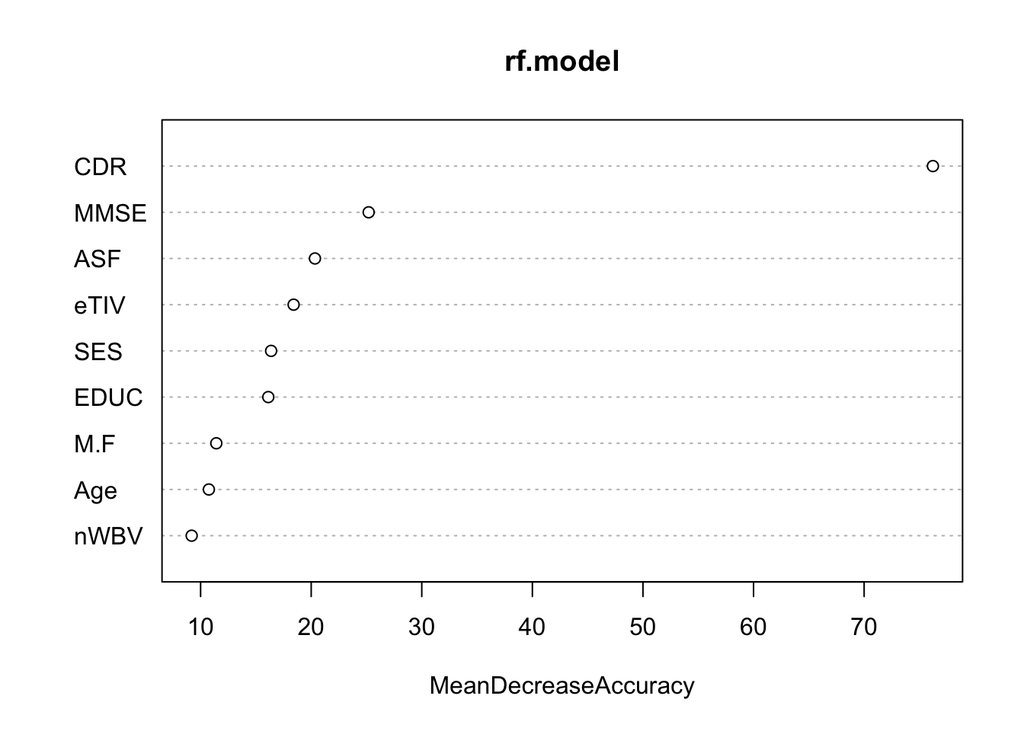

```r
varImpPlot(rf.model, type = 1)
```

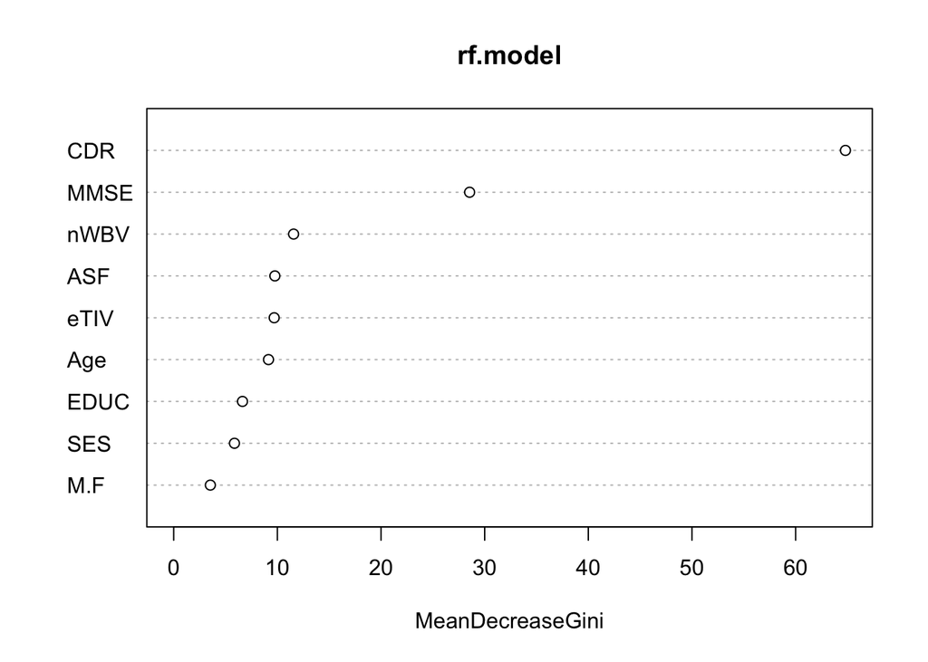

```r
varImpPlot(rf.model, type = 2)
```

### CDR, MMSE만 선택하여 학습시킨 모델과의 성능 비교

- MMSE: 미니멘탈 상태 검사(Mini Mental State Examination) 점수로, 인지 능력을 평가하기 위해 사용되는 검사 결과이다.
- CDR: 임상적 치매 평가(Clinical Dementia Rating)결과로, 치매의 심각성을 나타내는 지표이다.

#### 로지스틱회귀

```r
library(nnet)
logistic.model <- multinom(Group ~ CDR + MMSE, data = AD.tr)
logistic.predictions <- predict(logistic.model, newdata = AD.te)

# 예측 결과 평가
library(caret)
confusion_matrix <- confusionMatrix(logistic.predictions, AD.te$Group)
print(confusion_matrix)
```

```
## Confusion Matrix and Statistics
##
##              Reference
## Prediction    Converted Demented Nondemented
##   Converted           0        0           0
##   Demented            4       48           0
##   Nondemented         6        0          54
##
## Overall Statistics
##
##                Accuracy : 0.9107
##                  95% CI : (0.8419, 0.9564)
##     No Information Rate : 0.4821
##     P-Value [Acc > NIR] : < 2.2e-16
##
##                   Kappa : 0.8355
##
##  Mcnemar's Test P-Value : NA
##
## Statistics by Class:
##
##                      Class: Converted Class: Demented Class: Nondemented
## Sensitivity                   0.00000          1.0000             1.0000
## Specificity                   1.00000          0.9375             0.8966
## Pos Pred Value                    NaN          0.9231             0.9000
## Neg Pred Value                0.91071          1.0000             1.0000
## Prevalence                    0.08929          0.4286             0.4821
## Detection Rate                0.00000          0.4286             0.4821
## Detection Prevalence          0.00000          0.4643             0.5357
## Balanced Accuracy             0.50000          0.9688             0.9483
```

#### SVM

```r
tobj <- tune.svm(Group  ~ CDR + MMSE, data = AD.tr,
                kernel = "radial",
                gamma = 10^(-3:3),
                cost = 10^(-3:5))

print(tobj$best.parameters)
```

```
##    gamma cost
## 17   0.1  0.1
```

```r
svm.model <- svm(Group ~ CDR + MMSE, data = AD.tr,
                 kernel = "radial",
                 cost = tobj$best.parameters$cost,
                 gamma = tobj$best.parameters$gamma)


svm.predictions <- predict(svm.model, newdata = AD.te)

confusion_matrix <- confusionMatrix(svm.predictions, AD.te$Group)
print(confusion_matrix)
```

```
## Confusion Matrix and Statistics
##
##              Reference
## Prediction    Converted Demented Nondemented
##   Converted           0        0           0
##   Demented            4       48           0
##   Nondemented         6        0          54
##
## Overall Statistics
##
##                Accuracy : 0.9107
##                  95% CI : (0.8419, 0.9564)
##     No Information Rate : 0.4821
##     P-Value [Acc > NIR] : < 2.2e-16
##
##                   Kappa : 0.8355
##
##  Mcnemar's Test P-Value : NA
##
## Statistics by Class:
##
##                      Class: Converted Class: Demented Class: Nondemented
## Sensitivity                   0.00000          1.0000             1.0000
## Specificity                   1.00000          0.9375             0.8966
## Pos Pred Value                    NaN          0.9231             0.9000
## Neg Pred Value                0.91071          1.0000             1.0000
## Prevalence                    0.08929          0.4286             0.4821
## Detection Rate                0.00000          0.4286             0.4821
## Detection Prevalence          0.00000          0.4643             0.5357
## Balanced Accuracy             0.50000          0.9688             0.9483
```

#### Random Forest

```r
library(randomForest)

target <- AD.tr$Group
features <- AD.tr[, 6:7]

rf.model <- randomForest(x = features, y = target, importance = TRUE)
rf.predictions <- predict(rf.model, newdata = AD.te, type = "response")

confusion_matrix <- confusionMatrix(rf.predictions, AD.te$Group)
print(confusion_matrix)
```

```
## Confusion Matrix and Statistics
##
##              Reference
## Prediction    Converted Demented Nondemented
##   Converted           0        0           0
##   Demented            4       48           0
##   Nondemented         6        0          54
##
## Overall Statistics
##
##                Accuracy : 0.9107
##                  95% CI : (0.8419, 0.9564)
##     No Information Rate : 0.4821
##     P-Value [Acc > NIR] : < 2.2e-16
##
##                   Kappa : 0.8355
##
##  Mcnemar's Test P-Value : NA
##
## Statistics by Class:
##
##                      Class: Converted Class: Demented Class: Nondemented
## Sensitivity                   0.00000          1.0000             1.0000
## Specificity                   1.00000          0.9375             0.8966
## Pos Pred Value                    NaN          0.9231             0.9000
## Neg Pred Value                0.91071          1.0000             1.0000
## Prevalence                    0.08929          0.4286             0.4821
## Detection Rate                0.00000          0.4286             0.4821
## Detection Prevalence          0.00000          0.4643             0.5357
## Balanced Accuracy             0.50000          0.9688             0.9483
```

#### 1. 설명변수를 모두 사용한 경우

- 로지스틱 회귀 : 0.9375
- SVM : 0.9018
- RandomForest : 0.9286  
  ⇒ Confusion Matrix에서 볼 수 있듯 Demented / Nondemented 분류에 대해서는 틀리는 경우가 많지 않음 Converted를 Nondemented로 분류하는 경우가 많았음

#### 2. CDR, MMSE만을 설명변수로 사용한 경우

- 로지스틱 회귀 : 0.9107
- SVM : 0.9107
- RandomForest : 0.9107  
  ⇒ 세 모델에서 정확도뿐만 아니라 모든 평가지표가 동일한 값을 나타냄. 특히 Demented / Nondemented 분류는 100% 정확하게 예측하지만 Converted는 하나도 맞히지 못하는 결과를 볼 수 있음.